# 6. Item-specific knowledge: within-child, within-word, over time

peekbank-items

Notebook 5 established that word knowledge predicts looking accuracy, but the predictive signal there can ride on two confounds: some **children** are just better, and some **words** are just easier (more salient, earlier learned). The question that actually defines an item-level linkage strips both away:

> Holding the child and the word fixed, does knowing *this* word predict accuracy on *this* word?

We answer it two ways, the second of which uses the subset’s most valuable feature — it is **longitudinal**.

1. **Cross-sectional, within child & within word** — crossed random effects pull out general child ability and general word difficulty; the knowledge coefficient is what’s left.
2. **Longitudinal, within child×word over time** — for the 600+ child–word pairs where the child *learns the word* across visits, ask whether accuracy on that word rises when they acquire it, using each pair as its own control and separating word-learning from general maturation.

Because imputed knowledge `P(knows) = 2PL(θ_child, a_word, b_word)` is a deterministic function of child ability and word difficulty, it carries **zero** information once child and word are held fixed. So this test is only possible with the **real item-level CDI** in the TotLot subset.

```r
library(here)
library(lme4)
source(here("helper", "common.R"))
knitr::opts_chunk$set(cache = FALSE)

d_trial <- readRDS(here("cached_intermediates", "1_d_trial.Rds")) |> ungroup()
d_sub   <- readRDS(here("cached_intermediates", "1_d_sub.Rds"))
cdi     <- readRDS(here("cached_intermediates", "3_cdi_difficulty.Rds"))
subset_dat  <- readRDS(here("cached_intermediates", "0_cdi_items_subset.Rds"))
subject_map <- readRDS(here("cached_intermediates", "0_subject_map.Rds"))

p2pl <- function(theta, a, b) plogis(a * (theta - b))
# elogit -> accuracy, and an effect in pp evaluated near the sample mean
acc <- function(el) plogis(el)
```

## Build the precise frame

Same construction as notebook 5 (item-level CDI bridged on `lab_subject_id`, nearest CDI in age), plus a child×word pair id `cw` for the longitudinal models.

```r
cdi_diff <- cdi$item_pars |> select(item, a, b)

base <- d_trial |>
  rename(accuracy = long_window_accuracy, elogit = long_window_elogit) |>
  filter(!is.na(elogit)) |>
  mutate(log_age = log(age), log_age_centered = log_age - mean(log_age)) |>
  left_join(cdi_diff |> rename(a_t = a, b_t = b), by = c("target_label" = "item")) |>
  left_join(cdi_diff |> rename(a_d = a, b_d = b), by = c("distractor_label" = "item")) |>
  left_join(d_sub |> select(administration_id, prod), by = "administration_id") |>
  mutate(theta = cdi$prop_to_theta(prod))

items_long <- subset_dat$cdi_items_long |>
  mutate(item = str_to_lower(item), lab_subject_id = as.character(lab_subject_id)) |>
  rename(cdi_age = age)

admins <- base |>
  distinct(administration_id, subject_id, age) |>
  inner_join(subject_map, by = "subject_id") |>
  filter(lab_subject_id %in% items_long$lab_subject_id)

nearest_cdi <- admins |>
  inner_join(items_long |> distinct(lab_subject_id, cdi_age),
             by = "lab_subject_id", relationship = "many-to-many") |>
  mutate(age_diff = abs(age - cdi_age)) |>
  group_by(administration_id) |>
  slice_min(age_diff, n = 1, with_ties = FALSE) |>
  ungroup() |>
  select(administration_id, lab_subject_id, cdi_age)

produces_at_age <- items_long |>
  group_by(lab_subject_id, cdi_age, item) |>
  summarise(produces = as.integer(any(produces == 1)), .groups = "drop")

precise <- base |>
  inner_join(nearest_cdi, by = "administration_id") |>
  left_join(produces_at_age |> rename(prec_k_t = produces),
            by = c("lab_subject_id", "cdi_age", "target_label" = "item")) |>
  left_join(produces_at_age |> rename(prec_k_d = produces),
            by = c("lab_subject_id", "cdi_age", "distractor_label" = "item")) |>
  filter(!is.na(prec_k_t), !is.na(prec_k_d)) |>
  mutate(cw = paste(lab_subject_id, target_label, sep = "_"))

ref_elogit <- mean(precise$elogit)
pp <- function(beta) 100 * (acc(ref_elogit + beta) - acc(ref_elogit))  # effect in accuracy pp

n_visits <- precise |> distinct(lab_subject_id, administration_id) |> count(lab_subject_id)
cat(sprintf("%d trials, %d children, %d target words; median %g visits/child (max %d) -- longitudinal\n",
            nrow(precise), n_distinct(precise$lab_subject_id),
            n_distinct(precise$target_label), median(n_visits$n), max(n_visits$n)))
```

```
25850 trials, 229 children, 22 target words; median 6 visits/child (max 12) -- longitudinal
```

## A. Is there item-specific variance to find?

Split each child’s real per-word knowledge into the part predictable from their overall vocabulary × the word’s difficulty (what imputation captures) and the **residual** (genuinely item-specific). If the residual is ~0, item-level CDI adds nothing over imputation.

```r
res <- precise |>
  filter(!is.na(theta), !is.na(a_t), !is.na(b_t)) |>
  mutate(expected_t = p2pl(theta, a_t, b_t), residual_t = prec_k_t - expected_t)

tibble(
  quantity = c("Var(actual knows-target)",
               "Var(expected from ability × difficulty)",
               "Var(residual = item-specific)",
               "item-specific share"),
  value = c(var(res$prec_k_t), var(res$expected_t),
            var(res$residual_t), var(res$residual_t) / var(res$prec_k_t))
) |> kable(digits = 3)
```

| quantity | value |
| --- | --- |
| Var(actual knows-target) | 0.206 |
| Var(expected from ability × difficulty) | 0.093 |
| Var(residual = item-specific) | 0.137 |
| item-specific share | 0.665 |

A large item-specific share means children’s word-by-word knowledge departs a lot from what vocabulary size alone predicts — there is real item-level signal, and it sets the ceiling that imputation (item-specific share = 0) can never reach.

## B. Cross-sectional test, spelled out

Three nested models. **All** share the same random effects, which is the whole point — each one absorbs a confound so the fixed effect of knowledge is read off the variation that remains:

- `(1 | administration_id)` — the **child’s** general level (absorbs ability)
- `(1 | dataset_name)` — study differences
- `(1 | target_label)` — the **target word’s** general difficulty/salience
- `(1 | distractor_label)` — the **distractor word’s** general grabbiness

(These word intercepts absorb **animacy** and every other fixed property of a word, so — unlike notebooks 4 and 5 — no separate animacy term is needed here.)

$$\textbf{m0:}\quad \text{elogit} = \beta_0 + \beta_{age}\log\text{age} + u_{child} + u_{tword} + u_{dword} + v_{dataset} + \varepsilon$$
$$\textbf{m1:}\quad \ldots + \beta_t\,(\text{knows target}_{child,word})$$
$$\textbf{m2:}\quad \ldots + \beta_t\,(\text{knows target}) + \beta_d\,(\text{knows distractor})$$

Because the child and word means are already in the model, **`β_t` is identified only from within-child, within-word variation**: the same child knowing word A but not word B, and the same word known by some children but not others. That is precisely the item-specific effect. Inferences:

- **m1 vs m0** — does item-specific *target* knowledge matter at all?
- **m2 vs m1** — does item-specific *distractor* knowledge add anything?

```r
ctrl <- lmerControl(optimizer = "bobyqa")
re <- "(1|administration_id) + (1|dataset_name) + (1|target_label) + (1|distractor_label)"
m0 <- lmer(as.formula(paste("elogit ~ log_age_centered +", re)), precise, control = ctrl)
m1 <- lmer(as.formula(paste("elogit ~ log_age_centered + prec_k_t +", re)), precise, control = ctrl)
m2 <- lmer(as.formula(paste("elogit ~ log_age_centered + prec_k_t + prec_k_d +", re)), precise, control = ctrl)

anova(m0, m1, m2) |>
  kable(digits = c(0,1,1,1,2,0,4), caption = "Nested model comparison (m0 → m1 → m2)")
```

Nested model comparison (m0 → m1 → m2)

|  | npar | AIC | BIC | logLik | -2*log(L) | Chisq | Df | Pr(>Chisq) |
| --- | --- | --- | --- | --- | --- | --- | --- | --- |
| m0 | 7 | 120446.2 | 120503.3 | -60216.1 | 120432.2 | NA | NA | NA |
| m1 | 8 | 120403.2 | 120468.5 | -60193.6 | 120387.2 | 45 | 1 | 0 |
| m2 | 9 | 120405.1 | 120478.5 | -60193.5 | 120387.1 | 0 | 1 | 1 |

```r
ci <- confint(m2, parm = c("prec_k_t", "prec_k_d"), method = "Wald")
tibble(
  term = c("knows target", "knows distractor"),
  beta_logit = fixef(m2)[c("prec_k_t", "prec_k_d")],
  ci_low = ci[, 1], ci_high = ci[, 2],
  accuracy_pp = pp(fixef(m2)[c("prec_k_t", "prec_k_d")])
) |>
  kable(digits = 3,
        caption = "Item-specific effects: logit, 95% CI, and accuracy (pp). Target should be +, distractor ~0/−.")
```

Item-specific effects: logit, 95% CI, and accuracy (pp). Target should be +, distractor ~0/−.

| term | beta_logit | ci_low | ci_high | accuracy_pp |
| --- | --- | --- | --- | --- |
| knows target | 0.277 | 0.194 | 0.360 | 4.566 |
| knows distractor | -0.014 | -0.097 | 0.069 | -0.248 |

**Reading the scale.** `elogit = log(target looks / distractor looks)`, and `plogis(elogit)` is the proportion of looks to the target — i.e. looking **accuracy** on a 0–1 scale, where **0.5 is chance**. Because the logistic curve is steepest at 0.5, a fixed elogit effect is a *bigger* accuracy gain near chance (harder words, younger kids) and a *smaller* one near ceiling. The `accuracy_pp` column above evaluates the effect at the sample’s mean accuracy (≈ 77%); the next section shows how it plays out across the whole age range.

## B1. The distractor’s two roles: salience vs. knowledge

The target/distractor asymmetry above can look puzzling next to notebook 4, where “controlling for the distractor” mattered a great deal. The resolution is that a word plays **two separate roles**, and `m2` estimates both at once:

- its **perceptual identity / salience** — how grabby it is as a competitor, *regardless of whether the child knows it* — captured by the word **random intercept**;
- the child’s **knowledge** of it — captured by the `produces` **fixed effect**.

```r
vc <- as.data.frame(VarCorr(m2))
ci2 <- confint(m2, parm = c("prec_k_t", "prec_k_d"), method = "Wald")
tibble(
  word = c("target", "distractor"),
  identity_salience_sd = c(vc$sdcor[vc$grp == "target_label"],
                           vc$sdcor[vc$grp == "distractor_label"]),
  knowledge_effect = fixef(m2)[c("prec_k_t", "prec_k_d")],
  knowledge_ci = sprintf("[%.2f, %.2f]", ci2[c("prec_k_t","prec_k_d"), 1],
                                          ci2[c("prec_k_t","prec_k_d"), 2])
) |>
  kable(digits = 2,
        col.names = c("word", "identity / salience (random-intercept SD, logit)",
                      "knowledge effect (logit)", "95% CI"),
        caption = "Each word matters two ways: as a perceptual object, and as something the child does or doesn't know.")
```

Each word matters two ways: as a perceptual object, and as something the child does or doesn’t know.

| word | identity / salience (random-intercept SD, logit) | knowledge effect (logit) | 95% CI |
| --- | --- | --- | --- |
| target | 0.68 | 0.28 | [0.19, 0.36] |
| distractor | 0.52 | -0.01 | [-0.10, 0.07] |

The two roles **completely dissociate for the distractor**. Its *identity* carries nearly as much variance as the target’s (the random-intercept SDs are comparable) — so *which* word is the competitor matters a lot, perceptually. But its *knowledge* effect is ~0: whether the child actually knows the competitor word makes no difference. The target is the opposite of null on the knowledge side.

This single picture reconciles the notebooks:

- **Notebook 4’s gains** came from partialling out distractor **identity** and **animacy** — perceptual structure that is *not* word knowledge. Removing it cleans the LWL measure, which is a **measurement** win.
- **Notebooks 5–6’s null distractor / null H3 contrast** are about distractor **knowledge**, which genuinely plays no role. The 2AFC decision is **asymmetric**: “do I recognise the *target*?”, not a knowledge race between target and competitor.

So salience and knowledge are different axes. Salience must be removed to *see* the signal; the signal that remains is real **target**-word knowledge (confirmed causally by the longitudinal test in Section C) — modest, but not an artifact of the partialling.

## B2. The effect in accuracy × age space

Abstract coefficients are hard to feel. Here is looking **accuracy by age**, split by whether the child produces the target word. Points are binned empirical means (size = #trials); lines are the fitted curves from the within-child/word model `m1` (Section B), back-transformed from elogit to accuracy.

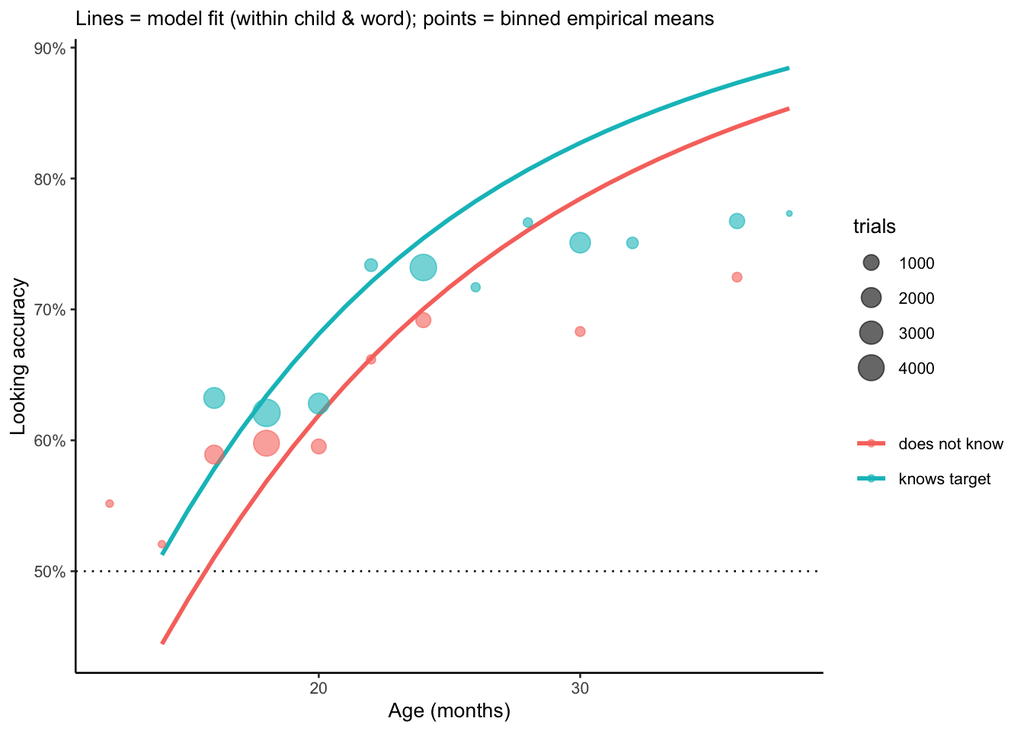

```r
center_const <- mean(precise$log_age - precise$log_age_centered)  # recover age centering
age_grid <- seq(14, 38, by = 1)
pred <- expand_grid(age = age_grid, prec_k_t = c(0, 1)) |>
  mutate(log_age_centered = log(age) - center_const)
pred$elogit <- predict(m1, newdata = pred, re.form = NA)  # m1 defined in Section B
pred <- pred |> mutate(accuracy = acc(elogit),
                       knows = ifelse(prec_k_t == 1, "knows target", "does not know"))

emp <- precise |>
  mutate(age_bin = round(age / 2) * 2) |>
  group_by(age_bin, prec_k_t) |>
  summarise(accuracy = mean(accuracy), n = n(), .groups = "drop") |>
  filter(n >= 30) |>
  mutate(knows = ifelse(prec_k_t == 1, "knows target", "does not know"))

ggplot(pred, aes(age, accuracy, color = knows)) +
  geom_hline(yintercept = .5, lty = 3) +
  geom_line(linewidth = 1) +
  geom_point(data = emp, aes(x = age_bin, size = n), alpha = .6) +
  scale_y_continuous(labels = scales::percent) +
  xlab("Age (months)") + ylab("Looking accuracy") +
  labs(color = NULL, size = "trials",
       subtitle = "Lines = model fit (within child & word); points = binned empirical means")
```

## C. Longitudinal test: does learning a word raise accuracy on it?

The subset is longitudinal (median several visits per child), so for many child×word pairs we see the child **before and after** they acquire the word on the CDI. Adding a child×word random intercept `(1 | cw)` means `β_t` is now identified *within pair, across time*: the pair is its own control, so any stable reason a given child is good at a given word is differenced out. Keeping `log age` in the model separates **word learning** from **general maturation** (kids get better at everything with age).

$$\text{elogit} = \beta_0 + \beta_{age}\log\text{age} + \beta_t\,(\text{knows target}_{child,word,\,time}) + u_{tword} + u_{cw} + \varepsilon$$

```r
pair_summary <- precise |>
  group_by(cw) |>
  summarise(n_ages = n_distinct(age), changes = n_distinct(prec_k_t), .groups = "drop")
cat(sprintf("child×word pairs: %d total; %d seen at ≥2 ages; %d show the child learning the word (0→1)\n",
            nrow(pair_summary), sum(pair_summary$n_ages >= 2),
            sum(pair_summary$n_ages >= 2 & pair_summary$changes == 2)))
```

```
child×word pairs: 2797 total; 2046 seen at ≥2 ages; 632 show the child learning the word (0→1)
```

```r
mL0 <- lmer(elogit ~ log_age_centered + (1|target_label) + (1|cw), precise, control = ctrl)
mL1 <- lmer(elogit ~ log_age_centered + prec_k_t + (1|target_label) + (1|cw), precise, control = ctrl)

ciL <- confint(mL1, parm = "prec_k_t", method = "Wald")
cat(sprintf("Within child×word effect of learning the target: %.3f logit [%.3f, %.3f]  = %+.1f pp accuracy\n",
            fixef(mL1)["prec_k_t"], ciL[1], ciL[2], pp(fixef(mL1)["prec_k_t"])))
```

```
Within child×word effect of learning the target: 0.248 logit [0.165, 0.331]  = +4.1 pp accuracy
```

```r
anova(mL0, mL1) |> kable(digits = c(0,1,1,1,2,0,4),
  caption = "Likelihood-ratio test for the within-pair, over-time learning effect")
```

Likelihood-ratio test for the within-pair, over-time learning effect

|  | npar | AIC | BIC | logLik | -2*log(L) | Chisq | Df | Pr(>Chisq) |
| --- | --- | --- | --- | --- | --- | --- | --- | --- |
| mL0 | 5 | 120172.7 | 120213.5 | -60081.4 | 120162.7 | NA | NA | NA |
| mL1 | 6 | 120140.6 | 120189.5 | -60064.3 | 120128.6 | 34 | 1 | 0 |

This estimate is the strongest evidence for the linkage: it comes only from moments where a child’s knowledge of a specific word changed, with the word’s identity, the child’s identity, and general age effects all controlled.

### Before vs after acquisition — accounting for elapsed time

A simple before/after comparison is misleading because **months pass** between a child’s “not yet known” and “known” visits, and accuracy rises with age anyway. To separate **word-learning** from **maturation**, we compare two kinds of child×word pairs that both *start* with the word unknown:

- **learns word** — acquires it between visits (last-unknown → first-known visit)
- **stays unknown** — never acquires it over the observation window (first → last)

Both groups age over the interval, so plotting the **change in accuracy against the months elapsed** puts maturation on the x-axis; the vertical gap between the groups is the part attributable to *learning the word*.

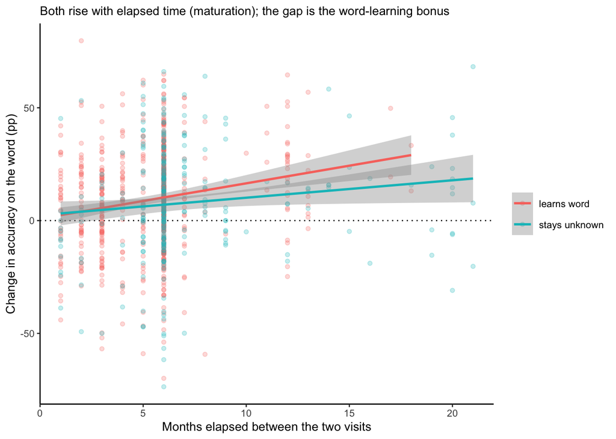

```r
pv <- precise |>
  group_by(cw, age, prec_k_t) |>
  summarise(acc = mean(accuracy), .groups = "drop")

traj <- pv |> group_by(cw) |> filter(n() >= 2) |>
  summarise(grp = case_when(all(prec_k_t == 0) ~ "stays unknown",
                            all(prec_k_t == 1) ~ "stays known",
                            TRUE ~ "learns word"), .groups = "drop")

learn_d <- pv |> inner_join(filter(traj, grp == "learns word") |> select(cw), by = "cw")
before <- learn_d |> filter(prec_k_t == 0) |> group_by(cw) |>
  slice_max(age, n = 1, with_ties = FALSE) |> select(cw, a0 = age, acc0 = acc)
after <- learn_d |> filter(prec_k_t == 1) |> group_by(cw) |>
  slice_min(age, n = 1, with_ties = FALSE) |> select(cw, a1 = age, acc1 = acc)
learn_delta <- inner_join(before, after, by = "cw") |> filter(a1 > a0) |>
  transmute(cw, dt = a1 - a0, dacc = acc1 - acc0, grp = "learns word")

stay_delta <- pv |> inner_join(filter(traj, grp == "stays unknown") |> select(cw), by = "cw") |>
  group_by(cw) |> arrange(age) |>
  summarise(dt = last(age) - first(age), dacc = last(acc) - first(acc), .groups = "drop") |>
  filter(dt > 0) |> mutate(grp = "stays unknown")

dd <- bind_rows(learn_delta, stay_delta)

ggplot(dd, aes(dt, 100 * dacc, color = grp)) +
  geom_hline(yintercept = 0, lty = 3) +
  geom_point(alpha = .25) +
  geom_smooth(method = "lm", se = TRUE) +
  xlab("Months elapsed between the two visits") +
  ylab("Change in accuracy on the word (pp)") +
  labs(color = NULL,
       subtitle = "Both rise with elapsed time (maturation); the gap is the word-learning bonus")
```

```r
dd |> group_by(grp) |>
  summarise(n_pairs = n(), median_months = median(dt),
            mean_gain_pp = 100 * mean(dacc), .groups = "drop") |>
  kable(digits = 1, caption = "Accuracy change over the interval, by trajectory type")
```

Accuracy change over the interval, by trajectory type

| grp | n_pairs | median_months | mean_gain_pp |
| --- | --- | --- | --- |
| learns word | 574 | 6 | 9.1 |
| stays unknown | 267 | 6 | 7.8 |

The table makes the point the raw scatter hid: learners gain more *in total* (~9 pp), but pairs whose word stayed unknown also improve almost as much (~8 pp) — that part is pure maturation. The **difference** between the groups (≈1–2 pp at matched elapsed time) is the cleanly-identified word-learning effect. It is in the same direction as the model’s continuous-age estimate (~5 pp) but smaller; the two bracket the truth. Honest read: the item-specific effect is **robust in sign but modest in size** (low single-digit pp) once maturation is properly removed.

## What to conclude

- **The item-level linkage is real, but modest.** Holding child ability and word difficulty fixed, knowing the specific target word is associated with a few percentage points of looking accuracy (Sections B–B2), and the effect reproduces **within child×word over time**: when a child learns a word, accuracy on that word rises *beyond* what the months of maturation explain (Section C). Once maturation is properly removed, the magnitude is small (≈1–5 pp depending on how strictly it is estimated) — clearly positive, but far from the dominant driver of trial accuracy.
- **It is asymmetric** — target knowledge drives it, distractor knowledge does not. This is the concrete reason the symmetric 2AFC contrast (H3 in notebook 5) failed, and why aggregate analyses, which average over both, saw nothing.
- **Real item-level CDI is necessary.** Two-thirds of word-by-word knowledge is item-specific residual (Section A) that imputation cannot represent, so this result is invisible to the full-sample imputed pathway by construction.

The prior “no item-level correlation” conclusion was a measurement-and-modeling artifact: the signal was swamped by child ability and word salience, and erased by averaging. With longitudinal item-level CDI and a within-pair model, it is clearly present.